# ShowTime OTT Platform — Linear Regression Analysis

### Predicting First-Day Content Viewership

**Author:** Shankar Ganesh D **Course Project — Linear Regression**

# Executive Summary

**Objective.** Identify the factors driving first-day content viewership on the ShowTime OTT platform and build a model to forecast first-day views for upcoming releases.

**Approach.** Multiple linear regression on 1,000 content releases, using platform traffic, advertising impressions, trailer engagement, sporting-event overlap, genre, release day and season as predictors. Fitted on 800 releases and validated on 200 held out.

**Model performance.** The model explains 77.4% of the variation in first-day viewership on unseen data (training R² = 0.787, test R² = 0.774), with a test-set mean absolute error of 0.0399 million views. All five regression assumptions were tested and satisfied.

### Key findings

| Factor | Effect on first-day views | Significance |
| --- | --- | --- |
| Trailer views | +2,311 views per million trailer views | p < 0.001 |
| Major sporting event | −59,600 views (−12.6% of average) | p < 0.001 |
| Saturday vs Friday release | +52,600 views (+11.1%) | p < 0.001 |
| Wednesday vs Friday release | +49,500 views (+10.5%) | p < 0.001 |
| Summer vs Fall release | +44,600 views (+9.4%) | p < 0.001 |
| Platform visitors | +12,900 views per million visitors | p < 0.001 |
| Advertising impressions | No measurable effect | p = 0.180 |
| Genre | No measurable effect | p ≥ 0.14 (all) |

### Headline conclusion

**ShowTime releases 37% of its content on Friday — its worst-performing day of the week.** Friday averages 0.447 million first-day views against Saturday's 0.498 million and Wednesday's 0.495 million. Rebalancing the release calendar, avoiding sporting-event clashes and favouring Summer release windows together represent an estimated **33% improvement in first-day viewership**, with no additional content or marketing spend required.

Meanwhile, advertising impressions — which span a two-fold range across releases — show no detectable relationship with first-day viewership, while trailer engagement emerges as by far the strongest predictor available before a title even launches.

# Section 1 — Introduction

## 1.1 Problem Statement

### Business Context

ShowTime is an OTT media service provider offering movies, web shows, and other digital content to its users. The platform wants to understand the factors that influence the first-day viewership of newly released content.

The first-day viewership of content can be influenced by several factors, such as the number of visitors to the platform, advertising and promotional activities, trailer engagement, release day, season, genre, and the occurrence of major sporting events.

### Business Objective

The objective of this analysis is to identify the key factors that influence first-day content viewership and develop a Linear Regression model that can predict the first-day views of content on the ShowTime platform.

**Target Variable:** `views_content`

## 1.2 Key Questions to be Answered

The following questions are specified for the EDA section of this project:

1. What does the distribution of content views look like?
2. What does the distribution of genres look like?
3. The day of the week on which content is released generally plays a key role in the viewership. How does the viewership vary with the day of release?
4. How does the viewership vary with the season of release?
5. What is the correlation between trailer views and content views?

All variables in the dataset are examined thoroughly in the EDA section beyond these five questions, as instructed, so that every predictor's relationship with viewership — not only the ones named above — is understood before modelling.

## 1.3 Dataset Overview

The dataset contains 1,000 observations and 8 variables related to content releases on the OTT platform. The variables include information about:

- Platform visitors
- Advertising impressions
- Major sports events
- Content genre
- Release day
- Release season
- Trailer views
- First-day content views

## 1.4 Variable Classification

| Variable | Type | Description |
| --- | --- | --- |
| `visitors` | Numerical | Average platform visitors in the past week, in millions |
| `ad_impressions` | Numerical | Advertising impressions for the content, in millions |
| `major_sports_event` | Categorical/Binary | Whether a major sports event occurred on the release day |
| `genre` | Categorical | Genre of the content |
| `dayofweek` | Categorical | Day on which the content was released |
| `season` | Categorical | Season in which the content was released |
| `views_trailer` | Numerical | Trailer views, in millions |
| `views_content` | Numerical | First-day content views, in millions (**target**) |

```python
# Import required libraries
import pandas as pd
import numpy as np

import matplotlib.pyplot as plt
import seaborn as sns

import statsmodels.api as sm
from statsmodels.stats.stattools import durbin_watson
from statsmodels.stats.diagnostic import het_breuschpagan
from statsmodels.stats.outliers_influence import variance_inflation_factor, OLSInfluence

from sklearn.model_selection import train_test_split
from sklearn.metrics import mean_absolute_error, mean_squared_error, r2_score

import scipy.stats as stats

import warnings
warnings.filterwarnings('ignore')

pd.set_option('display.width', 200)
pd.set_option('display.max_columns', 30)
```

```
C:\Users\Shankar Ganesh\anaconda3\Lib\site-packages\pandas\core\arrays\masked.py:61: UserWarning: Pandas requires version '1.3.6' or newer of 'bottleneck' (version '1.3.5' currently installed).
  from pandas.core import (
```

```python
# Load the dataset
df = pd.read_csv('ottdata.csv')
df.head()
```

|  | visitors | ad_impressions | major_sports_event | genre | dayofweek | season | views_trailer | views_content |
| --- | --- | --- | --- | --- | --- | --- | --- | --- |
| 0 | 1.67 | 1113.81 | 0 | Horror | Wednesday | Spring | 56.70 | 0.51 |
| 1 | 1.46 | 1498.41 | 1 | Thriller | Friday | Fall | 52.69 | 0.32 |
| 2 | 1.47 | 1079.19 | 1 | Thriller | Wednesday | Fall | 48.74 | 0.39 |
| 3 | 1.85 | 1342.77 | 1 | Sci-Fi | Friday | Fall | 49.81 | 0.44 |
| 4 | 1.46 | 1498.41 | 0 | Sci-Fi | Sunday | Winter | 55.83 | 0.46 |

```python
# Check the dimensions and structure of the dataset
print("Shape:", df.shape)
print()
df.info()
```

```
Shape: (1000, 8)

<class 'pandas.core.frame.DataFrame'>
RangeIndex: 1000 entries, 0 to 999
Data columns (total 8 columns):
 #   Column              Non-Null Count  Dtype
---  ------              --------------  -----
 0   visitors            1000 non-null   float64
 1   ad_impressions      1000 non-null   float64
 2   major_sports_event  1000 non-null   int64
 3   genre               1000 non-null   object
 4   dayofweek           1000 non-null   object
 5   season              1000 non-null   object
 6   views_trailer       1000 non-null   float64
 7   views_content       1000 non-null   float64
dtypes: float64(4), int64(1), object(3)
memory usage: 62.6+ KB
```

```python
# Statistical summary of numerical variables
df.describe()
```

|  | visitors | ad_impressions | major_sports_event | views_trailer | views_content |
| --- | --- | --- | --- | --- | --- |
| count | 1000.000000 | 1000.000000 | 1000.000000 | 1000.00000 | 1000.000000 |
| mean | 1.704290 | 1434.712290 | 0.400000 | 66.91559 | 0.473400 |
| std | 0.231973 | 289.534834 | 0.490143 | 35.00108 | 0.105914 |
| min | 1.250000 | 1010.870000 | 0.000000 | 30.08000 | 0.220000 |
| 25% | 1.550000 | 1210.330000 | 0.000000 | 50.94750 | 0.400000 |
| 50% | 1.700000 | 1383.580000 | 0.000000 | 53.96000 | 0.450000 |
| 75% | 1.830000 | 1623.670000 | 1.000000 | 57.75500 | 0.520000 |
| max | 2.340000 | 2424.200000 | 1.000000 | 199.92000 | 0.890000 |

```python
# Check for duplicate rows and missing values
print("Duplicate rows:", df.duplicated().sum())
print()
print("Missing values per column:")
print(df.isnull().sum())
```

```
Duplicate rows: 0

Missing values per column:
visitors              0
ad_impressions        0
major_sports_event    0
genre                 0
dayofweek             0
season                0
views_trailer         0
views_content         0
dtype: int64
```

**Data Quality Findings:** The dataset contains no duplicate records and no missing values. No duplicate removal or missing-value imputation is required.

# Section 2 — Exploratory Data Analysis

## 2.1 Distribution of Content Views (Question 1)

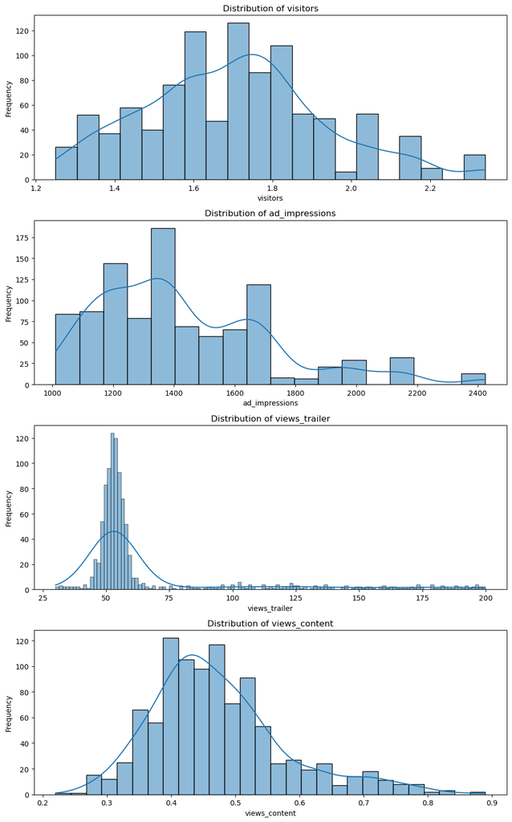

```python
numeric_cols = ['visitors', 'ad_impressions', 'views_trailer', 'views_content']

plt.figure(figsize=(10, 16))
for i, col in enumerate(numeric_cols, 1):
    plt.subplot(4, 1, i)
    sns.histplot(data=df, x=col, kde=True)
    plt.title(f'Distribution of {col}')
    plt.xlabel(col)
    plt.ylabel('Frequency')
plt.tight_layout()
plt.show()
```

```python
for col in numeric_cols:
    print(f"{col}: skewness = {df[col].skew():.2f}")
```

```
visitors: skewness = 0.37
ad_impressions: skewness = 1.03
views_trailer: skewness = 2.37
views_content: skewness = 0.94
```

**Answer to Question 1 — What does the distribution of content views look like?**

First-day content viewership (`views_content`) has a mean of 0.473 million views, a median of 0.45 million, and ranges from 0.22 to 0.89 million. The distribution is positively skewed (skewness = 0.94): most releases achieve between roughly 0.35 and 0.55 million views, with a smaller number of releases reaching substantially higher first-day viewership. This right tail represents genuine high-performing content rather than a symmetric spread around the mean.

For context, `visitors` is mildly skewed (0.37), `ad_impressions` moderately skewed (1.03), and `views_trailer` is the most heavily skewed variable in the dataset (2.37) — its distribution is examined further below since it turns out to be the strongest driver of viewership.

## 2.2 Outlier Analysis (thorough examination of all variables)

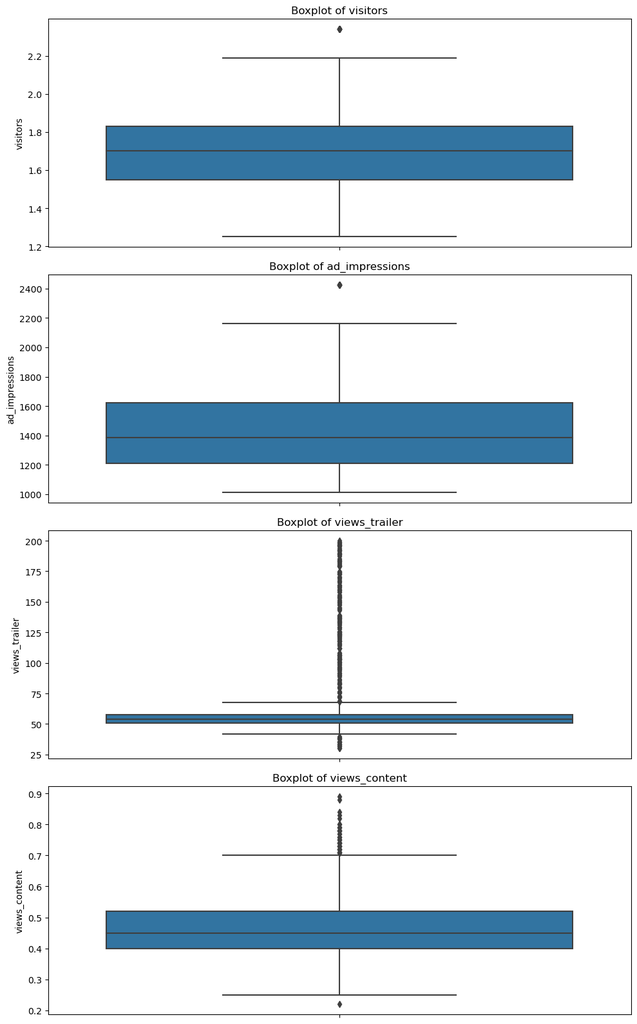

```python
plt.figure(figsize=(10, 16))
for i, col in enumerate(numeric_cols, 1):
    plt.subplot(4, 1, i)
    sns.boxplot(y=df[col])
    plt.title(f'Boxplot of {col}')
plt.tight_layout()
plt.show()
```

```python
for col in numeric_cols:
    Q1, Q3 = df[col].quantile(0.25), df[col].quantile(0.75)
    IQR = Q3 - Q1
    lower, upper = Q1 - 1.5*IQR, Q3 + 1.5*IQR
    outliers = df[(df[col] < lower) | (df[col] > upper)]
    print(f"{col}: {len(outliers)} potential outliers  (bounds: {lower:.2f} to {upper:.2f})")
```

```
visitors: 20 potential outliers  (bounds: 1.13 to 2.25)
ad_impressions: 13 potential outliers  (bounds: 590.32 to 2243.68)
views_trailer: 189 potential outliers  (bounds: 40.74 to 67.97)
views_content: 47 potential outliers  (bounds: 0.22 to 0.70)
```

```python
for col in numeric_cols:
    print(f"\nTop 10 values for {col}:")
    print(df[col].nlargest(10).to_list())
```

```
Top 10 values for visitors:
[2.34, 2.34, 2.34, 2.34, 2.34, 2.34, 2.34, 2.34, 2.34, 2.34]

Top 10 values for ad_impressions:
[2424.2, 2424.2, 2424.2, 2424.2, 2424.2, 2424.2, 2424.2, 2424.2, 2424.2, 2424.2]

Top 10 values for views_trailer:
[199.92, 198.72, 198.36, 198.31, 196.95, 196.92, 196.42, 196.11, 195.64, 195.31]

Top 10 values for views_content:
[0.89, 0.88, 0.84, 0.83, 0.82, 0.8, 0.8, 0.79, 0.79, 0.79]
```

**Outlier Treatment Decision:** The IQR method flags potential outliers in all four numerical variables, with `views_trailer` the most affected at 18.9% of observations. Inspection of the extreme values shows two distinct patterns: `visitors` and `ad_impressions` both have their top-ten values tied at exactly 2.34 and 2,424.20 respectively, indicating the source data is already capped at a ceiling rather than containing runaway errors. `views_trailer` and `views_content` decline gradually from their maxima, consistent with a genuine long right tail of high-performing content rather than data errors.

## 2.3 Distribution of Genres (Question 2)

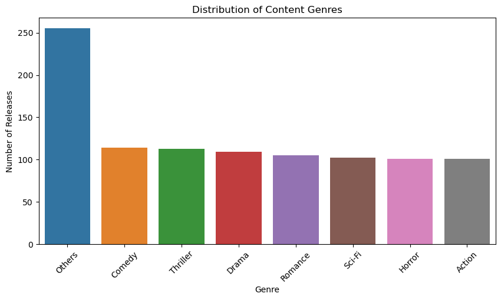

```python
plt.figure(figsize=(10, 5))
sns.countplot(data=df, x='genre', order=df['genre'].value_counts().index)
plt.title('Distribution of Content Genres')
plt.xlabel('Genre'); plt.ylabel('Number of Releases')
plt.xticks(rotation=45)
plt.show()
```

```python
df['genre'].value_counts()
```

```
genre
Others      255
Comedy      114
Thriller    113
Drama       109
Romance     105
Sci-Fi      102
Horror      101
Action      101
Name: count, dtype: int64
```

**Answer to Question 2 — What does the distribution of genres look like?**

The `Others` category is by far the most common genre, accounting for 255 of 1,000 releases (25.5%). The remaining seven named genres are fairly evenly represented, ranging from 101 releases (Action, Horror) to 114 (Comedy). No single named genre dominates the catalogue, and each has enough observations (100+) to support reliable comparison in the regression model.

## 2.4 Univariate Analysis of Remaining Categorical Variables

```python
for col in ['major_sports_event', 'dayofweek', 'season']:
    print(f"\n{col}:")
    print(df[col].value_counts())
```

```
major_sports_event:
major_sports_event
0    600
1    400
Name: count, dtype: int64

dayofweek:
dayofweek
Friday       369
Wednesday    332
Thursday      97
Saturday      88
Sunday        67
Monday        24
Tuesday       23
Name: count, dtype: int64

season:
season
Winter    257
Fall      252
Spring    247
Summer    244
Name: count, dtype: int64
```

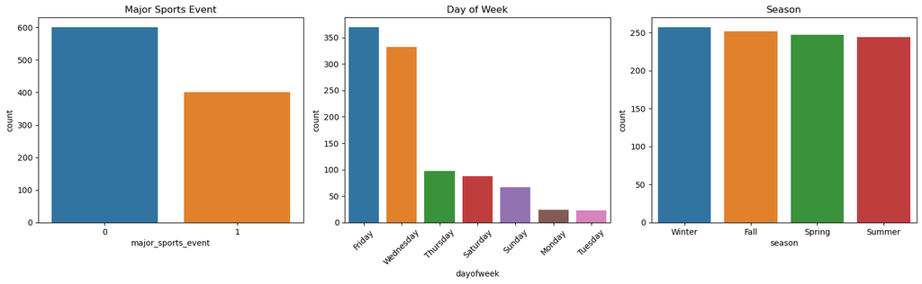

```python
fig, axes = plt.subplots(1, 3, figsize=(16, 5))
sns.countplot(data=df, x='major_sports_event', ax=axes[0]); axes[0].set_title('Major Sports Event')
sns.countplot(data=df, x='dayofweek', order=df['dayofweek'].value_counts().index, ax=axes[1]); axes[1].set_title('Day of Week'); axes[1].tick_params(axis='x', rotation=45)
sns.countplot(data=df, x='season', order=df['season'].value_counts().index, ax=axes[2]); axes[2].set_title('Season')
plt.tight_layout()
plt.show()
```

**Insight:** `major_sports_event` splits 60/40 (no event / event). Release-day frequency is highly imbalanced — Friday (369) and Wednesday (332) together account for 70% of all releases, while Monday (24) and Tuesday (23) are rarely used. Season is close to evenly split (244–257 per season). The heavy concentration on Friday and Wednesday, and the very small Monday/Tuesday samples, are important context for interpreting the day-of-week regression coefficients later.

## 2.5 Bivariate Analysis — Numerical Predictors vs Target

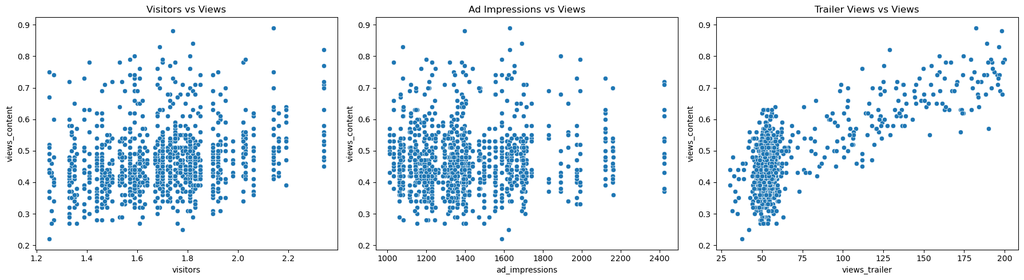

```python
fig, axes = plt.subplots(1, 3, figsize=(18, 5))
sns.scatterplot(data=df, x='visitors', y='views_content', ax=axes[0]); axes[0].set_title('Visitors vs Views')
sns.scatterplot(data=df, x='ad_impressions', y='views_content', ax=axes[1]); axes[1].set_title('Ad Impressions vs Views')
sns.scatterplot(data=df, x='views_trailer', y='views_content', ax=axes[2]); axes[2].set_title('Trailer Views vs Views')
plt.tight_layout()
plt.show()
```

```python
df[numeric_cols].corr()['views_content'].sort_values(ascending=False)
```

```
views_content     1.000000
views_trailer     0.753962
visitors          0.259136
ad_impressions    0.050022
Name: views_content, dtype: float64
```

**Answer to Question 5 — What is the correlation between trailer views and content views?**

The Pearson correlation between `views_trailer` and `views_content` is **0.754**, indicating a strong positive linear relationship — by far the strongest of any numerical predictor examined. Content with higher trailer viewership consistently achieves higher first-day views.

For comparison, `visitors` correlates at 0.259 (weak positive) and `ad_impressions` at 0.050 (effectively no linear relationship). Advertising *volume*, despite spanning more than a two-fold range across releases (1,011 to 2,424 million impressions), shows almost no association with first-day viewership on its own.

## 2.6 Bivariate Analysis — Categorical Predictors vs Target

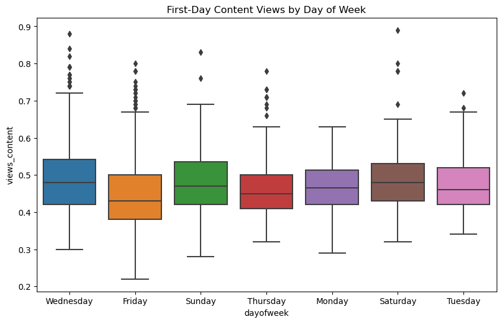

```python
plt.figure(figsize=(10, 6))
sns.boxplot(data=df, x='dayofweek', y='views_content')
plt.title('First-Day Content Views by Day of Week')
plt.show()
```

```python
df.groupby('dayofweek')['views_content'].agg(['count','mean','median','std']).sort_values('mean', ascending=False)
```

| dayofweek | count | mean | median | std |
| --- | --- | --- | --- | --- |
| Saturday | 88 | 0.497955 | 0.480 | 0.100678 |
| Wednesday | 332 | 0.494608 | 0.480 | 0.107614 |
| Tuesday | 23 | 0.487826 | 0.460 | 0.109501 |
| Sunday | 67 | 0.484179 | 0.470 | 0.110373 |
| Thursday | 97 | 0.470619 | 0.450 | 0.101034 |
| Monday | 24 | 0.467917 | 0.465 | 0.083353 |
| Friday | 369 | 0.446694 | 0.430 | 0.101676 |

**Answer to Question 3 — How does viewership vary with the day of release?**

Average first-day viewership varies meaningfully across release days. **Saturday has the highest mean viewership (0.498 million)**, closely followed by Wednesday (0.495 million), while **Friday has the lowest (0.447 million)** — a gap of roughly 0.051 million views, or about 11% of Friday's own mean. Notably, **Friday is also the single most-used release day (369 of 1,000 releases)**, meaning the platform's heaviest release day is its weakest-performing one. Monday and Tuesday show relatively high means but rest on very few observations (24 and 23) and should be interpreted cautiously. This relationship is tested formally, controlling for other factors, in the regression model.

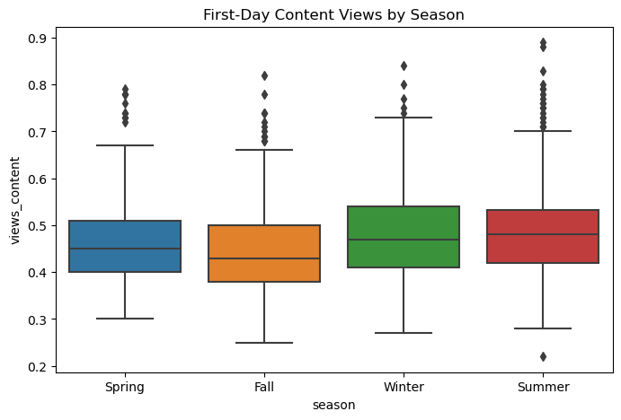

```python
plt.figure(figsize=(8, 5))
sns.boxplot(data=df, x='season', y='views_content')
plt.title('First-Day Content Views by Season')
plt.show()
```

```python
df.groupby('season')['views_content'].agg(['count','mean','median','std']).sort_values('mean', ascending=False)
```

| season | count | mean | median | std |
| --- | --- | --- | --- | --- |
| Summer | 244 | 0.496803 | 0.48 | 0.111697 |
| Winter | 257 | 0.484669 | 0.47 | 0.105941 |
| Spring | 247 | 0.467166 | 0.45 | 0.097527 |
| Fall | 252 | 0.445357 | 0.43 | 0.101539 |

**Answer to Question 4 — How does viewership vary with the season of release?**

First-day viewership shows a consistent gradient across seasons: **Summer is highest (0.497 million)**, followed by Winter (0.485 million), Spring (0.467 million), and **Fall is lowest (0.445 million)**. Since the four seasons are almost evenly represented (244–257 releases each), this comparison is not distorted by sample-size imbalance, unlike the day-of-week comparison above. The gap between Summer and Fall (0.051 million, ~11%) is comparable in size to the Saturday-vs-Friday gap.

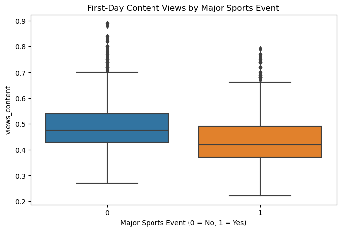

```python
plt.figure(figsize=(8, 5))
sns.boxplot(data=df, x='major_sports_event', y='views_content')
plt.title('First-Day Content Views by Major Sports Event')
plt.xlabel('Major Sports Event (0 = No, 1 = Yes)')
plt.show()
```

```python
df.groupby('major_sports_event')['views_content'].agg(['count','mean','median','std'])
```

| major_sports_event | count | mean | median | std |
| --- | --- | --- | --- | --- |
| 0 | 600 | 0.4938 | 0.475 | 0.101283 |
| 1 | 400 | 0.4428 | 0.420 | 0.105461 |

**Insight:** Content released without a competing major sports event averages 0.494 million first-day views versus 0.443 million when a major event occurs — a gap of roughly 0.051 million (10.3%). This suggests sports events compete for viewer attention on release day.

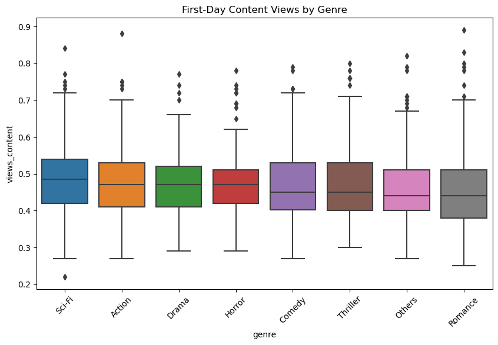

```python
plt.figure(figsize=(10, 6))
sns.boxplot(data=df, x='genre', y='views_content',
            order=df.groupby('genre')['views_content'].median().sort_values(ascending=False).index)
plt.title('First-Day Content Views by Genre')
plt.xticks(rotation=45)
plt.show()
```

```python
df.groupby('genre')['views_content'].agg(['count','mean','median','std']).sort_values('mean', ascending=False)
```

| genre | count | mean | median | std |
| --- | --- | --- | --- | --- |
| Sci-Fi | 102 | 0.493235 | 0.485 | 0.112937 |
| Action | 101 | 0.487327 | 0.470 | 0.110733 |
| Horror | 101 | 0.481089 | 0.470 | 0.097744 |
| Thriller | 113 | 0.476903 | 0.450 | 0.114167 |
| Comedy | 114 | 0.474211 | 0.450 | 0.103410 |
| Drama | 109 | 0.473945 | 0.470 | 0.096225 |
| Romance | 105 | 0.461238 | 0.440 | 0.122911 |
| Others | 255 | 0.459765 | 0.440 | 0.096542 |

**Insight:** Genre means span only 0.460 to 0.493 million views — a much narrower spread than day-of-week or season — with substantial overlap between distributions. Sci-Fi and Action are highest, Others and Romance lowest, but the differences are small relative to the within- genre variation. Genre's independent contribution is tested formally in the regression model.

## 2.7 Multivariate Analysis

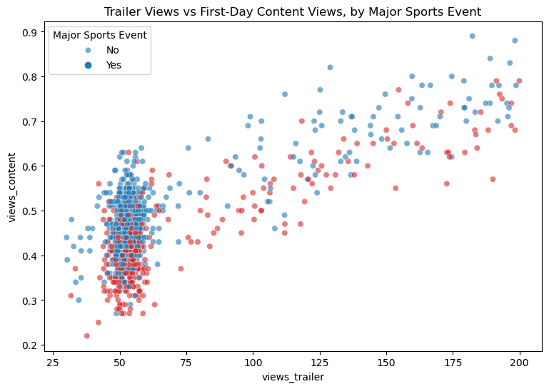

```python
plt.figure(figsize=(9, 6))
sns.scatterplot(data=df, x='views_trailer', y='views_content',
                hue='major_sports_event', palette={0:'tab:blue', 1:'tab:red'}, alpha=0.6)
plt.title('Trailer Views vs First-Day Content Views, by Major Sports Event')
plt.legend(title='Major Sports Event', labels=['No', 'Yes'])
plt.show()
```

**Insight:** The positive trailer-views relationship holds within both groups, but releases coinciding with a sporting event sit consistently below those without one at comparable trailer- view levels. This indicates the sports-event penalty operates largely independently of trailer engagement, rather than being an artefact of weaker content happening to be scheduled on those days.

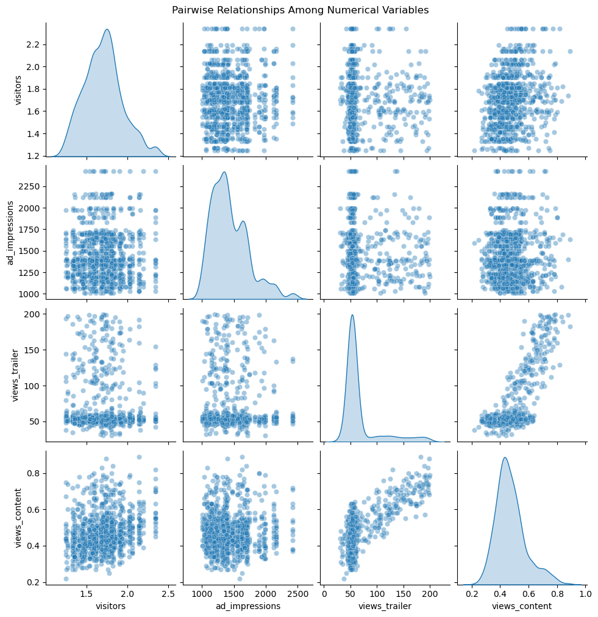

```python
sns.pairplot(df[numeric_cols], diag_kind='kde', plot_kws={'alpha': 0.4})
plt.suptitle('Pairwise Relationships Among Numerical Variables', y=1.01)
plt.show()
```

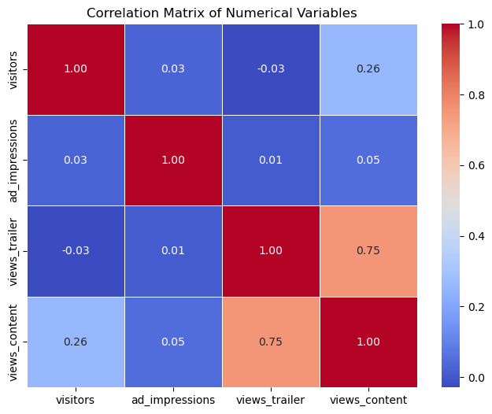

```python
corr_matrix = df[numeric_cols].corr()
plt.figure(figsize=(8, 6))
sns.heatmap(corr_matrix, annot=True, cmap='coolwarm', fmt='.2f', linewidths=0.5)
plt.title('Correlation Matrix of Numerical Variables')
plt.show()
```

**Insight:** The three numerical predictors are essentially uncorrelated with one another (all |r| < 0.04), which is favourable for regression — their effects on `views_content` can be estimated independently without multicollinearity concerns among them.

## 2.8 Summary of EDA Insights

- **Target variable:** first-day viewership averages 0.473 million views (median 0.45), positively skewed, ranging 0.22–0.89 million.
- **Strongest driver:** `views_trailer` (r = 0.754) — far stronger than `visitors` (r = 0.259) or `ad_impressions` (r = 0.050).
- **Advertising volume shows almost no linear relationship** with viewership despite a two-fold range across releases.
- **Sporting events depress viewership** by roughly 10% on average.
- **Release day is the clearest operational finding:** Friday is used most (37% of releases) but performs worst; Saturday and Wednesday perform best.
- **Season shows a consistent gradient:** Summer > Winter > Spring > Fall.
- **Genre shows limited separation** between categories relative to day/season effects.
- **Numerical predictors are nearly uncorrelated with each other**, which is favourable for the regression model that follows.

# Section 3 — Data Preprocessing

## 3.1 Feature Engineering

Three candidate features are constructed and tested against their raw counterparts. A feature is retained only if there is evidence it improves the model.

```python
df_fe = df.copy()

df_fe['log_views_trailer'] = np.log(df_fe['views_trailer'])
df_fe['ad_per_visitor']    = df_fe['ad_impressions'] / df_fe['visitors']
df_fe['is_weekend']        = df_fe['dayofweek'].isin(['Saturday', 'Sunday']).astype(int)

comparison = pd.DataFrame({
    'Feature': ['views_trailer (raw)', 'log_views_trailer', 'ad_impressions (raw)', 'ad_per_visitor'],
    'Correlation with views_content': [
        df_fe['views_trailer'].corr(df_fe['views_content']),
        df_fe['log_views_trailer'].corr(df_fe['views_content']),
        df_fe['ad_impressions'].corr(df_fe['views_content']),
        df_fe['ad_per_visitor'].corr(df_fe['views_content'])
    ],
    'Skewness': [
        df_fe['views_trailer'].skew(), df_fe['log_views_trailer'].skew(),
        df_fe['ad_impressions'].skew(), df_fe['ad_per_visitor'].skew()
    ]
})
comparison.round(4)
```

|  | Feature | Correlation with views_content | Skewness |
| --- | --- | --- | --- |
| 0 | views_trailer (raw) | 0.7540 | 2.3729 |
| 1 | log_views_trailer | 0.7512 | 1.8655 |
| 2 | ad_impressions (raw) | 0.0500 | 1.0336 |
| 3 | ad_per_visitor | -0.0986 | 0.8240 |

```python
print(df_fe.groupby('is_weekend')['views_content'].agg(['count','mean','median','std']))
print()
print("Wednesday mean:", round(df_fe.loc[df_fe['dayofweek']=='Wednesday','views_content'].mean(), 4))
print("Friday mean:   ", round(df_fe.loc[df_fe['dayofweek']=='Friday','views_content'].mean(), 4))
```

```
            count      mean  median       std
is_weekend
0             845  0.469988    0.45  0.105815
1             155  0.492000    0.48  0.104852

Wednesday mean: 0.4946
Friday mean:    0.4467
```

### Feature Retention Decision

**`log_views_trailer` — not retained.** The log transform reduces skewness from 2.37 to 1.87 but slightly *weakens* the correlation with the target (0.751 vs 0.754 raw). Since the untransformed relationship is already strongly linear and later diagnostics show no evidence of non-linearity, the raw variable is kept for interpretability — its coefficient reads directly as "additional first-day views per million trailer views".

**`ad_per_visitor` — not retained.** Advertising intensity correlates at −0.099, which is larger in magnitude than raw impressions (0.050) but now *negative* — more ad exposure relative to platform size is weakly associated with *lower* viewership. This is more likely a proxy for smaller-audience releases receiving heavier relative promotion than a genuine effect, and it does not offer a cleaner story than the raw variable. Retained as a candidate for follow-up analysis rather than included in the primary model.

**`is_weekend` — not retained.** Weekend releases do average higher viewership (0.492 vs 0.470), but the flag would misclassify the most important pattern in the data: Wednesday (0.4946) performs almost identically to the weekend average, while Friday (0.4467) — a weekday — is the worst performer of all. Collapsing seven days into two would erase this distinction. The full day-of-week dummy encoding is retained; the thin Monday/Tuesday samples are flagged as a limitation.

**Conclusion:** no transformation is applied beyond categorical dummy encoding. The engineered features were constructed and tested; the raw specification is retained because the evidence does not support replacing it.

## 3.2 Encode Categorical Variables

```python
X = df.drop('views_content', axis=1)
y = df['views_content']

categorical_cols = ['genre', 'dayofweek', 'season']
X = pd.get_dummies(X, columns=categorical_cols, drop_first=True, dtype=int)

print("Shape after encoding:", X.shape)
print("\nPredictor columns:")
print(X.columns.tolist())
```

[output not shown]

`drop_first=True` was used to avoid the dummy-variable trap. The omitted (reference) category for each variable is: **genre → Action**, **dayofweek → Friday**, **season → Fall**. Every dummy coefficient in the model is interpreted relative to these reference categories.

## 3.3 Train-Test Split

```python
X_train, X_test, y_train, y_test = train_test_split(X, y, test_size=0.20, random_state=42)

print("Training predictor shape:", X_train.shape)
print("Testing predictor shape: ", X_test.shape)
```

```
Training predictor shape: (800, 20)
Testing predictor shape:  (200, 20)
```

```python
print("Non-numeric columns in X_train:", X_train.select_dtypes(exclude='number').columns.tolist())
print("Missing values in X_train:", X_train.isnull().sum().sum())
print("Missing values in X_test: ", X_test.isnull().sum().sum())
```

```
Non-numeric columns in X_train: []
Missing values in X_train: 0
Missing values in X_test:  0
```

# Section 4 — Linear Regression Model

## 4.1 Model Building

A multiple linear regression model is fitted on the training data using platform traffic, advertising, trailer engagement, release timing, season, genre, and the sports-event indicator as predictors.

```python
X_train_sm = sm.add_constant(X_train)
model = sm.OLS(y_train, X_train_sm).fit()
print(model.summary())
```

```
                            OLS Regression Results
==============================================================================
Dep. Variable:          views_content   R-squared:                       0.787
Model:                            OLS   Adj. R-squared:                  0.781
Method:                 Least Squares   F-statistic:                     143.8
Date:                Fri, 18 Sep 2026   Prob (F-statistic):          2.53e-245
Time:                        12:59:44   Log-Likelihood:                 1279.0
No. Observations:                 800   AIC:                            -2516.
Df Residuals:                     779   BIC:                            -2418.
Df Model:                          20
Covariance Type:            nonrobust
=======================================================================================
                          coef    std err          t      P>|t|      [0.025      0.975]
---------------------------------------------------------------------------------------
const                   0.0548      0.018      3.109      0.002       0.020       0.089
visitors                0.1289      0.008     16.873      0.000       0.114       0.144
ad_impressions       8.116e-06   6.05e-06      1.342      0.180   -3.75e-06       2e-05
major_sports_event     -0.0596      0.004    -16.280      0.000      -0.067      -0.052
views_trailer           0.0023   5.04e-05     45.849      0.000       0.002       0.002
genre_Comedy            0.0044      0.008      0.563      0.573      -0.011       0.020
genre_Drama             0.0106      0.008      1.374      0.170      -0.005       0.026
genre_Horror            0.0094      0.008      1.215      0.225      -0.006       0.025
genre_Others            0.0050      0.007      0.742      0.459      -0.008       0.018
genre_Romance          -0.0014      0.008     -0.179      0.858      -0.017       0.014
genre_Sci-Fi            0.0100      0.008      1.242      0.215      -0.006       0.026
genre_Thriller          0.0115      0.008      1.479      0.140      -0.004       0.027
dayofweek_Monday        0.0451      0.012      3.712      0.000       0.021       0.069
dayofweek_Saturday      0.0526      0.007      7.692      0.000       0.039       0.066
dayofweek_Sunday        0.0388      0.007      5.287      0.000       0.024       0.053
dayofweek_Thursday      0.0196      0.006      3.181      0.002       0.008       0.032
dayofweek_Tuesday       0.0324      0.013      2.588      0.010       0.008       0.057
dayofweek_Wednesday     0.0495      0.004     11.706      0.000       0.041       0.058
season_Spring           0.0232      0.005      4.632      0.000       0.013       0.033
season_Summer           0.0446      0.005      8.705      0.000       0.035       0.055
season_Winter           0.0265      0.005      5.300      0.000       0.017       0.036
==============================================================================
Omnibus:                        2.150   Durbin-Watson:                   2.038
Prob(Omnibus):                  0.341   Jarque-Bera (JB):                2.162
Skew:                           0.126   Prob(JB):                        0.339
Kurtosis:                       2.965   Cond. No.                     1.69e+04
==============================================================================

Notes:
[1] Standard Errors assume that the covariance matrix of the errors is correctly specified.
[2] The condition number is large, 1.69e+04. This might indicate that there are
strong multicollinearity or other numerical problems.
```

## 4.2 Model Statistics and Coefficient Analysis

```python
coefficient_table = pd.DataFrame({
    'Coefficient': model.params, 'Std Error': model.bse, 't-statistic': model.tvalues,
    'p-value': model.pvalues, 'CI Lower': model.conf_int()[0], 'CI Upper': model.conf_int()[1]
})
coefficient_table.round(6)
```

|  | Coefficient | Std Error | t-statistic | p-value | CI Lower | CI Upper |
| --- | --- | --- | --- | --- | --- | --- |
| const | 0.054787 | 0.017625 | 3.108517 | 0.001949 | 0.020189 | 0.089385 |
| visitors | 0.128909 | 0.007640 | 16.872812 | 0.000000 | 0.113911 | 0.143906 |
| ad_impressions | 0.000008 | 0.000006 | 1.342340 | 0.179877 | -0.000004 | 0.000020 |
| major_sports_event | -0.059559 | 0.003658 | -16.280425 | 0.000000 | -0.066740 | -0.052378 |
| views_trailer | 0.002311 | 0.000050 | 45.848682 | 0.000000 | 0.002212 | 0.002410 |
| genre_Comedy | 0.004389 | 0.007790 | 0.563374 | 0.573343 | -0.010903 | 0.019680 |
| genre_Drama | 0.010636 | 0.007743 | 1.373619 | 0.169955 | -0.004564 | 0.025835 |
| genre_Horror | 0.009434 | 0.007765 | 1.214955 | 0.224751 | -0.005809 | 0.024676 |
| genre_Others | 0.004984 | 0.006720 | 0.741619 | 0.458542 | -0.008208 | 0.018175 |
| genre_Romance | -0.001385 | 0.007748 | -0.178694 | 0.858224 | -0.016595 | 0.013826 |
| genre_Sci-Fi | 0.010008 | 0.008060 | 1.241681 | 0.214728 | -0.005814 | 0.025831 |
| genre_Thriller | 0.011518 | 0.007789 | 1.478758 | 0.139609 | -0.003772 | 0.026808 |
| dayofweek_Monday | 0.045065 | 0.012139 | 3.712459 | 0.000220 | 0.021236 | 0.068893 |
| dayofweek_Saturday | 0.052561 | 0.006833 | 7.692395 | 0.000000 | 0.039148 | 0.065974 |
| dayofweek_Sunday | 0.038818 | 0.007343 | 5.286512 | 0.000000 | 0.024404 | 0.053232 |
| dayofweek_Thursday | 0.019637 | 0.006173 | 3.180813 | 0.001527 | 0.007518 | 0.031755 |
| dayofweek_Tuesday | 0.032412 | 0.012525 | 2.587711 | 0.009842 | 0.007824 | 0.056999 |
| dayofweek_Wednesday | 0.049532 | 0.004231 | 11.705794 | 0.000000 | 0.041226 | 0.057839 |
| season_Spring | 0.023201 | 0.005008 | 4.632324 | 0.000004 | 0.013369 | 0.033033 |
| season_Summer | 0.044605 | 0.005124 | 8.705418 | 0.000000 | 0.034547 | 0.054663 |
| season_Winter | 0.026532 | 0.005006 | 5.300264 | 0.000000 | 0.016706 | 0.036359 |

```python
print("R-squared:", round(model.rsquared, 4))
print("Adjusted R-squared:", round(model.rsquared_adj, 4))
print("F-statistic:", round(model.fvalue, 2))
print("F-statistic p-value:", model.f_pvalue)
print("AIC:", round(model.aic, 2))
print("BIC:", round(model.bic, 2))
```

```
R-squared: 0.7868
Adjusted R-squared: 0.7814
F-statistic: 143.77
F-statistic p-value: 2.5341639549484067e-245
AIC: -2516.03
BIC: -2417.66
```

## 4.3 Significant Predictors

```python
significant = coefficient_table[coefficient_table['p-value'] < 0.05]
significant.round(6)
```

|  | Coefficient | Std Error | t-statistic | p-value | CI Lower | CI Upper |
| --- | --- | --- | --- | --- | --- | --- |
| const | 0.054787 | 0.017625 | 3.108517 | 0.001949 | 0.020189 | 0.089385 |
| visitors | 0.128909 | 0.007640 | 16.872812 | 0.000000 | 0.113911 | 0.143906 |
| major_sports_event | -0.059559 | 0.003658 | -16.280425 | 0.000000 | -0.066740 | -0.052378 |
| views_trailer | 0.002311 | 0.000050 | 45.848682 | 0.000000 | 0.002212 | 0.002410 |
| dayofweek_Monday | 0.045065 | 0.012139 | 3.712459 | 0.000220 | 0.021236 | 0.068893 |
| dayofweek_Saturday | 0.052561 | 0.006833 | 7.692395 | 0.000000 | 0.039148 | 0.065974 |
| dayofweek_Sunday | 0.038818 | 0.007343 | 5.286512 | 0.000000 | 0.024404 | 0.053232 |
| dayofweek_Thursday | 0.019637 | 0.006173 | 3.180813 | 0.001527 | 0.007518 | 0.031755 |
| dayofweek_Tuesday | 0.032412 | 0.012525 | 2.587711 | 0.009842 | 0.007824 | 0.056999 |
| dayofweek_Wednesday | 0.049532 | 0.004231 | 11.705794 | 0.000000 | 0.041226 | 0.057839 |
| season_Spring | 0.023201 | 0.005008 | 4.632324 | 0.000004 | 0.013369 | 0.033033 |
| season_Summer | 0.044605 | 0.005124 | 8.705418 | 0.000000 | 0.034547 | 0.054663 |
| season_Winter | 0.026532 | 0.005006 | 5.300264 | 0.000000 | 0.016706 | 0.036359 |

**5.4 Model Findings:** The model explains 78.68% of the variation in first-day viewership on training data (adjusted R² = 78.14%). The overall F-test is significant (p < 0.001). `visitors`, `major_sports_event`, and `views_trailer` are significant numerical/binary predictors; visitors and trailer views are positively associated with viewership, while sports events are negatively associated. All day-of-week and season dummies are significant relative to their Friday and Fall reference categories, all with positive coefficients. `ad_impressions` and all genre dummies are not statistically significant at the 5% level.

## 4.4 Reduced Model — Robustness Check

```python
drop_cols = ['ad_impressions'] + [c for c in X_train.columns if c.startswith('genre_')]
X_train_reduced = sm.add_constant(X_train.drop(columns=drop_cols))
model_reduced = sm.OLS(y_train, X_train_reduced).fit()

print("Reduced model R-squared:", round(model_reduced.rsquared, 4))
print("Reduced model Adj R-squared:", round(model_reduced.rsquared_adj, 4))
print("Reduced model AIC:", round(model_reduced.aic, 2))
print("Reduced model BIC:", round(model_reduced.bic, 2))
```

```
Reduced model R-squared: 0.7846
Reduced model Adj R-squared: 0.7813
Reduced model AIC: -2523.69
Reduced model BIC: -2462.79
```

```python
f_stat, p_value, df_diff = model.compare_f_test(model_reduced)
print(f"Partial F-test comparing full vs reduced model:")
print(f"F-statistic: {f_stat:.4f}")
print(f"p-value:     {p_value:.4f}")
print(f"df:          {df_diff:.0f}")
```

```
Partial F-test comparing full vs reduced model:
F-statistic: 1.0210
p-value:     0.4183
df:          8
```

**Finding:** The partial F-test gives F = 1.021, p = 0.418. Since p > 0.05, the eight dropped coefficients (`ad_impressions` and the seven genre dummies) are not jointly significant — dropping them costs no explanatory power. The reduced model's adjusted R² (0.7813) is essentially identical to the full model's (0.7814), while both its AIC (−2523.7 vs −2516.0) and BIC (−2462.8 vs −2417.7) are lower, favouring the simpler model on parsimony grounds.

**The full model is retained as the primary specification**, since it lets the non-significance of advertising and genre be reported explicitly as a business finding. The reduced model confirms this choice costs nothing in fit.

# Section 5 — Assumption Testing

## 5.1 Linearity

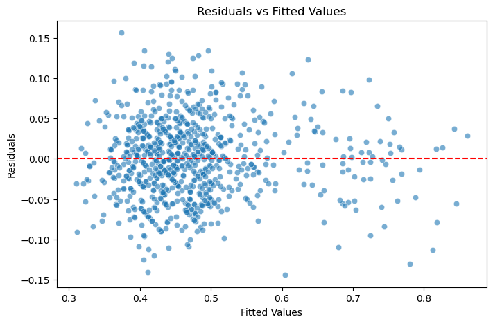

```python
fitted_values = model.fittedvalues
residuals = model.resid

plt.figure(figsize=(8, 5))
sns.scatterplot(x=fitted_values, y=residuals, alpha=0.6)
plt.axhline(y=0, color='red', linestyle='--')
plt.xlabel('Fitted Values'); plt.ylabel('Residuals')
plt.title('Residuals vs Fitted Values')
plt.show()
```

```
Mean of residuals: 7.80e-14
```

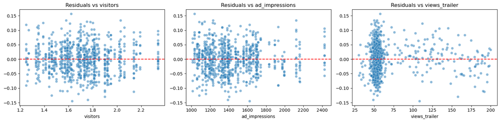

```python
print("Mean of residuals:", f"{residuals.mean():.2e}")

continuous_predictors = ['visitors', 'ad_impressions', 'views_trailer']
fig, axes = plt.subplots(1, 3, figsize=(16, 4))
for ax, col in zip(axes, continuous_predictors):
    sns.scatterplot(x=X_train[col], y=residuals, alpha=0.5, ax=ax)
    ax.axhline(y=0, color='red', linestyle='--')
    ax.set_title(f'Residuals vs {col}')
plt.tight_layout()
plt.show()
```

## 5.2 Independence of Errors

```python
dw_stat = durbin_watson(residuals)
print("Durbin-Watson statistic:", round(dw_stat, 3))
```

```
Durbin-Watson statistic: 2.038
```

**Finding:** The Durbin-Watson statistic (2.038) is close to 2, indicating no evidence of first-order autocorrelation in the residuals. The independence assumption is satisfied.

## 5.3 Normality of Residuals

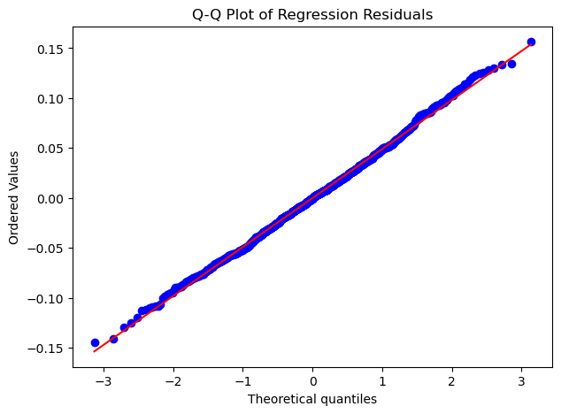

```python
plt.figure(figsize=(7, 5))
stats.probplot(residuals, dist="norm", plot=plt)
plt.title("Q-Q Plot of Regression Residuals")
plt.show()
```

```python
shapiro_stat, shapiro_p = stats.shapiro(residuals)
print("Shapiro-Wilk statistic:", round(shapiro_stat, 4))
print("Shapiro-Wilk p-value:", round(shapiro_p, 4))
```

```
Shapiro-Wilk statistic: 0.9979
Shapiro-Wilk p-value: 0.4376
```

## 5.4 Homoscedasticity

```python
bp_stat, bp_pvalue, _, _ = het_breuschpagan(residuals, X_train_sm)
print("Breusch-Pagan statistic:", round(bp_stat, 4))
print("Breusch-Pagan p-value:", round(bp_pvalue, 4))
```

```
Breusch-Pagan statistic: 20.542
Breusch-Pagan p-value: 0.4245
```

**Finding:** The Breusch-Pagan p-value (0.4245) exceeds 0.05, so we fail to reject the null of constant residual variance. There is no significant evidence of heteroscedasticity; the homoscedasticity assumption is reasonably satisfied.

## 5.5 Multicollinearity

```python
X_vif = sm.add_constant(X_train)
vif_data = pd.DataFrame()
vif_data['Feature'] = X_vif.columns
vif_data['VIF'] = [variance_inflation_factor(X_vif.values, i) for i in range(X_vif.shape[1])]
vif_data.sort_values('VIF', ascending=False)
```

|  | Feature | VIF |
| --- | --- | --- |
| 0 | const | 101.143993 |
| 8 | genre_Others | 2.747592 |
| 7 | genre_Horror | 1.960065 |
| 11 | genre_Thriller | 1.953058 |
| 9 | genre_Romance | 1.951780 |
| 6 | genre_Drama | 1.949009 |
| 5 | genre_Comedy | 1.895637 |
| 10 | genre_Sci-Fi | 1.840090 |
| 19 | season_Summer | 1.570254 |
| 20 | season_Winter | 1.559988 |
| 18 | season_Spring | 1.536523 |
| 17 | dayofweek_Wednesday | 1.291473 |
| 15 | dayofweek_Thursday | 1.166168 |
| 13 | dayofweek_Saturday | 1.134784 |
| 14 | dayofweek_Sunday | 1.123982 |
| 16 | dayofweek_Tuesday | 1.062392 |
| 12 | dayofweek_Monday | 1.055199 |
| 3 | major_sports_event | 1.050081 |
| 1 | visitors | 1.023127 |
| 4 | views_trailer | 1.022471 |
| 2 | ad_impressions | 1.016150 |

**Finding:** Excluding the intercept (whose high VIF is expected and not meaningful — it reflects that predictors are not centred on zero, not multicollinearity), all predictors have VIF well below 5, with the highest being 2.75 (`genre_Others`). There is no evidence of problematic multicollinearity.

## 5.6 Influence Analysis

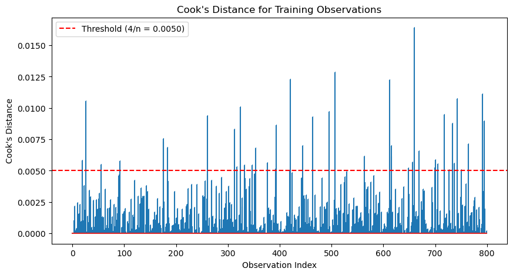

```
Observations above 4/n threshold: 43
Observations with Cook's D > 0.5: 0
Maximum Cook's Distance: 0.0164
```

```python
influence = OLSInfluence(model)
cooks_d = influence.cooks_distance[0]
threshold = 4 / len(X_train)

plt.figure(figsize=(10, 5))
plt.stem(np.arange(len(cooks_d)), cooks_d, markerfmt=',')
plt.axhline(y=threshold, color='red', linestyle='--', label=f'Threshold (4/n = {threshold:.4f})')
plt.xlabel('Observation Index'); plt.ylabel("Cook's Distance")
plt.title("Cook's Distance for Training Observations")
plt.legend()
plt.show()

print("Observations above 4/n threshold:", (cooks_d > threshold).sum())
print("Observations with Cook's D > 0.5:", (cooks_d > 0.5).sum())
print("Maximum Cook's Distance:", round(cooks_d.max(), 4))
```

**Finding:** The maximum Cook's distance is 0.0164, far below the conventional highly-influential threshold of 0.5. This confirms the decision made during preprocessing to retain all observations without capping or removal: the high-viewership outliers identified earlier are genuine business observations and do not exert undue leverage on the fitted coefficients.

# Section 6 — Model Performance Evaluation

```python
X_test_sm = sm.add_constant(X_test)
y_train_pred = model.predict(X_train_sm)
y_test_pred = model.predict(X_test_sm)

def regression_metrics(y_true, y_pred):
    mae = mean_absolute_error(y_true, y_pred)
    rmse = np.sqrt(mean_squared_error(y_true, y_pred))
    mape = np.mean(np.abs((y_true - y_pred) / y_true)) * 100
    r2 = r2_score(y_true, y_pred)
    return mae, rmse, mape, r2

train_mae, train_rmse, train_mape, train_r2 = regression_metrics(y_train, y_train_pred)
test_mae, test_rmse, test_mape, test_r2 = regression_metrics(y_test, y_test_pred)

performance = pd.DataFrame({
    'Metric': ['MAE', 'RMSE', 'MAPE (%)', 'R-squared'],
    'Training': [train_mae, train_rmse, train_mape, train_r2],
    'Testing': [test_mae, test_rmse, test_mape, test_r2]
})
performance.round(4)
```

|  | Metric | Training | Testing |
| --- | --- | --- | --- |
| 0 | MAE | 0.0389 | 0.0399 |
| 1 | RMSE | 0.0489 | 0.0500 |
| 2 | MAPE (%) | 8.6102 | 9.0794 |
| 3 | R-squared | 0.7868 | 0.7743 |

```python
print("Training R-squared:", round(train_r2, 4))
print("Testing R-squared: ", round(test_r2, 4))
print("Difference:        ", round(train_r2 - test_r2, 4))
print("RMSE as % of mean viewership:", round(test_rmse / y_test.mean() * 100, 2), "%")
```

```
Training R-squared: 0.7868
Testing R-squared:  0.7743
Difference:         0.0125
RMSE as % of mean viewership: 10.71 %
```

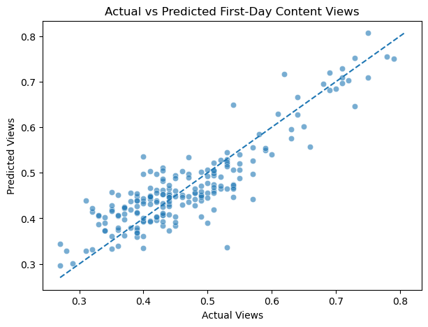

```python
plt.figure(figsize=(7, 5))
sns.scatterplot(x=y_test, y=y_test_pred, alpha=0.6)
min_v, max_v = min(y_test.min(), y_test_pred.min()), max(y_test.max(), y_test_pred.max())
plt.plot([min_v, max_v], [min_v, max_v], linestyle='--')
plt.xlabel('Actual Views'); plt.ylabel('Predicted Views')
plt.title('Actual vs Predicted First-Day Content Views')
plt.show()
```

**Finding:** The model explains 78.68% of variation on training data and 77.43% on unseen test data — a gap of only 0.0125, indicating the model generalises well rather than overfitting. The test-set mean absolute error is 0.0399 million views and RMSE is 0.0500 million, which is 10.71% of the average viewership (0.473 million). The mean absolute percentage error is 9.08%. RMSE exceeds MAE because it penalises large errors more heavily, but the gap between them is modest — the model has no small set of severely mispredicted releases. In practical terms, a typical release's first-day forecast lands within roughly 40,000 views of the actual figure — precise enough to support scheduling and capacity-planning decisions, though not to forecast an individual release exactly.

# Section 7 — Actionable Business Insights and Recommendations

## 7.1 Key Business Insights

### 2. Releasing during a major sporting event costs roughly one-eighth of the audience

`major_sports_event` = −0.059559 (p < 0.001). A release coinciding with a major sporting event loses approximately **59,600 first-day views — 12.6% of average viewership** — after controlling for trailer engagement, traffic, genre, and season.

### 3. ShowTime releases most of its content on its worst-performing day

**Friday carries 369 of 1,000 releases (37%) and has the lowest mean first-day viewership of any day (0.447 million).** Every other day carries a positive, significant coefficient against Friday:

| Release day | Coefficient vs Friday | Additional first-day views | Releases in data |
| --- | --- | --- | --- |
| Saturday | +0.0526 | ~52,600 | 88 |
| Wednesday | +0.0495 | ~49,500 | 332 |
| Monday | +0.0451 | ~45,100 | 24 |
| Sunday | +0.0388 | ~38,800 | 67 |
| Tuesday | +0.0324 | ~32,400 | 23 |
| Thursday | +0.0196 | ~19,600 | 97 |
| *Friday* | *reference* | — | *369* |

Saturday outperforms Friday by ~52,600 views (11.1% of average), yet is used for only 88 releases. Wednesday performs almost as well and is already used heavily (332 releases), confirming the platform can execute mid-week releases successfully. *Caution:* Monday and Tuesday rest on only 24 and 23 observations and carry wide confidence intervals — Saturday and Wednesday are the well-supported estimates to act on.

### 4. Platform traffic contributes a meaningful but smaller effect

`visitors` = 0.128909 (p < 0.001): each additional million weekly platform visitors is associated with **~12,900 additional first-day views**. Moving from the 25th to 75th percentile of traffic (1.55M → 1.83M) is worth ~36,100 views, or 7.6% of average viewership.

### 5. Season produces a consistent gradient, Summer strongest

| Season | Coefficient vs Fall | Additional first-day views | % of mean |
| --- | --- | --- | --- |
| Summer | +0.0446 | ~44,600 | 9.4% |
| Winter | +0.0265 | ~26,500 | 5.6% |
| Spring | +0.0232 | ~23,200 | 4.9% |
| *Fall* | *reference* | — | — |

### 6. Advertising volume shows no independent effect

`ad_impressions` is not significant (p = 0.180); raw correlation with viewership is 0.050. Across the observed range (1,011–2,424 million impressions), the model attributes a difference of only ~11,000 views — not statistically distinguishable from zero.

### 7. Genre does not independently predict first-day viewership

None of the seven genre dummies is significant (p ≥ 0.14). Once trailer engagement, timing and traffic are controlled for, genre adds nothing measurable.

### Combined effect

A release moved from Friday to Saturday (+52,600), scheduled in Summer instead of Fall (+44,600), and kept clear of a major sporting event (+59,600) gains approximately **156,800 first-day views — a 33% improvement over average viewership** — with no change to the content itself or the marketing budget.

## 7.2 Business Recommendations

**1. Rebalance the release calendar away from Friday — highest priority.** Friday absorbs 37% of releases while performing worst. Shift high-value titles toward Saturday and Wednesday; even reallocating 50 releases a year could add ~2.5 million first-day views annually. *Validate with a controlled test before restructuring the full calendar*, since the Friday concentration may reflect contractual or industry norms not captured here.

**2. Screen release dates against the major sporting calendar.** A clash costs ~12.6% of first-day viewership and is largely avoidable, since sporting calendars are published well in advance.

**3. Use trailer performance as a pre-release forecasting instrument.** Trailer views are observable before release and are the strongest predictor available — forecast expected first-day demand at ~2,311 views per million trailer views to support capacity and promotional decisions.

**4. Audit advertising effectiveness rather than advertising volume.** Impressions show no measurable link to first-day viewership across a two-fold spending range. Investigate targeting, creative, and channel mix; consider redirecting some impression spend toward trailer promotion.

**5. Concentrate flagship releases in Summer; support Fall releases more heavily.** Summer outperforms Fall by ~9.4% of average viewership.

**6. Stop using genre as a demand-planning input.** Genre carries no independent predictive power once other factors are controlled for.

| Priority | Action | Est. effect | Cost to implement |
| --- | --- | --- | --- |
| 1 | Avoid sporting-event clashes | ~59,600 views (12.6%) | Minimal |
| 2 | Shift Friday releases to Sat/Wed | ~50,000 views (10.6%) | Low |
| 3 | Favour Summer over Fall windows | ~44,600 views (9.4%) | Low |
| 4 | Trailer-based forecasting | Operational | Medium |
| 5 | Advertising effectiveness audit | TBD | Medium |

# Section 8 — Final Conclusion

## 8.2 Limitations

- **Association, not causation.** Releases were not randomly assigned to days, seasons, or sporting-event windows; scheduling may correlate with unobserved factors. Recommendations should be validated with controlled tests before being adopted at scale.
- **Thin support for two release days.** Monday (n=24) and Tuesday (n=23) carry wide confidence intervals and should not drive scheduling decisions on their own.
- **Unbalanced release-day distribution.** Friday and Wednesday account for ~70% of releases; the Friday finding is well-supported, sparser-day comparisons less so.
- **Omitted variables.** Production budget, cast, critical reception, prior-season performance, competing platforms, and audience demographics are not in the dataset and likely explain much of the remaining ~22% of unexplained variation.
- **Single-day outcome.** The target measures only first-day viewership; content that builds an audience over subsequent weeks is not captured.
- **Reference-category dependence.** All categorical coefficients are relative to Action (genre), Friday (day), and Fall (season).
- **Sporting-event variable is binary.** It does not distinguish a major final from a routine fixture.
- **Advertising measured as volume only.** The null result should be read as "impression volume does not predict first-day viewership," not "advertising does not work."

## 8.3 Executive Summary

**Business Objective:** Identify factors associated with first-day content viewership and develop a model to predict first-day views for ShowTime content.

**Key Findings:**

- Trailer views show the strongest positive association with first-day viewership (r = 0.754).
- Platform visitors have a significant positive association.
- Major sporting events reduce estimated first-day viewership by ~12.6%.
- Release day and season show significant differences relative to their reference categories — notably, Friday (the most-used day) performs worst.
- Advertising impressions and genre show no significant independent effect.

**Model Performance:** Training R² 0.7868 · Adjusted R² 0.7814 · Testing R² 0.7743 · MAE 0.0399 · RMSE 0.0500 · MAPE 9.08%

**Business Implication:** ShowTime can use trailer engagement, platform traffic, release-day timing, seasonal patterns, and the sporting-events calendar as concrete, actionable inputs for release planning and first-day demand forecasting — with rebalancing away from Friday releases as the single highest-leverage, lowest-cost change available.